# GEOG 5680 6680 12 Spatial data in R

Simon Brewer Geography Department University of Utah

May 02, 2020

## Introduction

In this lab, we will explore some of R’s functions for working with spatial data. R has been extensively developed to work with spatial data, and this is one thing that distinguishes from many other analytical languages. You should be aware, however, that R is currently transitioning away from the data formats described in this document to use a new set based on [simple features](https://r-spatial.github.io/sf/articles/sf1.html). However, as this is still in progress, and as the majority of the spatial analytical tools (e.g. spatial regression, hotspot analysis) do not yet use these formats, we’ll stick here with the oder formats based on the **sp** package.

Remember to use RStudio’s script editor (top left panel) to enter your commands and then copy-paste these to the console when you are ready. This will keep a copy of the commands that you can save and return to.

Before starting, remember to create a working directory (e.g. `module12`). Next download the files for today’s lab from the Canvas page and move them to this directory. You’ll need the following files:

- Climate dataset for Western North America: *WNAclimate.csv*
- Temperature dataset for Oregon in shapefile format: *oregon.zip*
- New York state polygon data in a shapefile: *NY_Data.zip*
- A shapefile of country borders: *ne_50m_admin_0_countries.zip*
- A shapefile of Switzerland: *borders.zip*
- Digital elevation map from Switzerland: *swiss_dem.grd*
- A NetCDF file of global monthly air temperature: *air.mon.ltm.nc*

Make sure that you unzip the zip files. As a warning - sometimes Windows adds an extra recursive folder when it extracts files from a zip file. For example, if you unzip the file called *borders.zip* this should make a folder called `borders` with some files in it. Windows may make a double directory (`borders\borders`). If R can’t find some of the files in the examples, it might be worth checking this.

Base R has no structure for spatial data, so you will need to install the following packages:

- **sp**
- **maptools**
- **rgdal**
- **raster**
- **RColorBrewer**
- **classInt**
- **ggmap**

## Spatial Objects

The **sp** package provides S4 spatial objects - these are R objects that can hold spatial information (e.g. coordinates, projection information) as well as data. There are several of these objects, and the following section introduces the main types.

### SpatialPoint* Objects

Read in the WNA Climate dataset from the csv file *WNAclimate.csv*, and use the `names()` function to see the columns in the dataframe:

```r
wnaclim <- read.csv("WNAclimate.csv")
names(wnaclim)
```

```
## [1] "WNASEQ"   "LONDD"    "LATDD"    "ELEV"     "totsnopt" "annp"     "Jan_Tmp"
## [8] "Jul_Tmp"
```

We now create a simple SpatialPoint object of the location of the sites in the dataframe using the `SpatialPoints()` function. Note that we first create a coordinate reference system (CRS) for the data (here, simple longitude/latitude on a WGS84 sphere).

```r
library(rgdal)
llCRS <- CRS("+proj=longlat +ellps=WGS84")
wnaclim.sp <- SpatialPoints(cbind(wnaclim$LONDD, wnaclim$LATDD),
                            proj4string=llCRS)
summary(wnaclim.sp)
```

```
## Object of class SpatialPoints
## Coordinates:
##                 min  max
## coords.x1 -138.0000 -100
## coords.x2   29.8333   60
## Is projected: FALSE
## proj4string : [+proj=longlat +ellps=WGS84]
## Number of points: 2012
```

There are some standard functions to obtain basic data and metadata about any Spatial* object:

```r
bbox(wnaclim.sp)
proj4string(wnaclim.sp)
coordinates(wnaclim.sp)
```

The original dataframe also contains various other parameters (elevation, climate, site name) in columns that we can associated with the SpatialPoints, by creating a SpatialPointsDataFrame.

```r
wnaclim.spdf <- SpatialPointsDataFrame(cbind(wnaclim$LONDD,
                                             wnaclim$LATDD),
                                       wnaclim, proj4string=llCRS)
summary(wnaclim.spdf)
```

Now we have a spatial object with associated values, we can make some plots. Using R’s basic `plot()` function with any spatial data will simply plot the spatial geometry:

```r
plot(wnaclim.spdf)
```

The **sp** package has a function to make thematic maps. For this we need to specify the Spatial* object and the column name or attribute to use. Note that both this and the `plot()` function will adapt to different spatial data types.

```r
spplot(wnaclim.spdf, "Jan_Tmp", colorkey=TRUE)
spplot(wnaclim.spdf, "Jul_Tmp", colorkey=TRUE)
```

As the attributes for these locations are held as a data frame, we can use all the standard R functions with them. For example, to calculate the mean and standard deviation of January temperatures:

```r
mean(wnaclim.spdf$Jan_Tmp)
```

```
## [1] -3.375149
```

```r
sd(wnaclim.spdf$Jan_Tmp)
```

```
## [1] 7.382896
```

And to plot a histogram of annual precipitation:

```r
hist(wnaclim.spdf$annp, main="W.NAm Annual Precipitation", breaks=20)
```

### SpatialPolygon* Objects

You can create your own polygonss using a combination of the `Polygon()` and the `SpatialPolygon()` function. However, it is generally easier to import polygons that have been created by GIS software. Shapefiles are one of the most commonly used formats, and the **rgdal** package includes a function (`readOGR()`) for reading these directly into R. This fucntion will read most standard spatial data formats, and you can see the full set of vector formats that can be read by typing `ogrDrivers()` at the console.

The zip file `NY_data.zip` contains shapefiles for part of the state of New York. Unzip this in your current working directory, then read in the data as follows:

```r
NY8 <- readOGR("NY_data/NY8_utm18.shp")
class(NY8)
summary(NY8)
```

This creates a SpatialPolygonDataFrame; a polygon object with spatial attributes and an associated data frame. As the shapefile had an associated file with projection information (a `*.prj` file), the projection is automatically set in R.

```r
proj4string(NY8)
```

Which tells us that file is in a UTM Zone 18 projection. As in the previous example, this object has an associated data frame containing attributes, and we can use this like any standard R data frame. If, for example, we want to calculate the total population:

```r
sum(NY8$POP8)
```

```
## [1] 1057673
```

We can again use `spplot()` to make a thematic map by specifying which column or attribute we want to use:

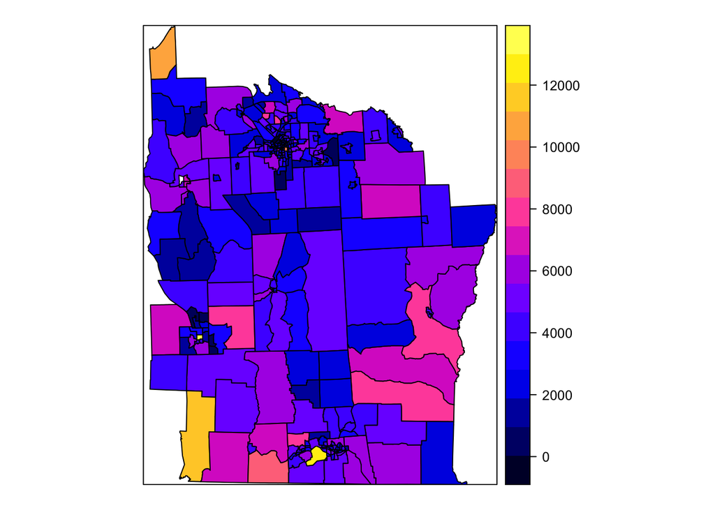

```r
spplot(NY8, "POP8")
```

If we are only interested in a subset of the data, we can use the attributes to select polygons. The data frame contains a column with the district associated with each polygon. If we only want the subset corresponding to Syracuse, we can extract this as follows:

```r
Syracuse <- NY8[NY8$AREANAME == "Syracuse city", ]
plot(Syracuse)
spplot(Syracuse, "POP8")
```

Or we can select by an attribute. For example to extract only the polygons with over 15% population ages 65 and over (this is the variable ‘PCTAGE65P’):

```r
Pop65p <- Syracuse[Syracuse$PCTAGE65P > 0.15, ]
plot(Pop65p)
spplot(Pop65p, "PCTAGE65P")
```

### SpatialGrid* Objects

As with the other types of objects, SpatialGrid objects exist with and without associated data frames. The first type (SpatialGridDataFrames) are used for storing raster data (remote sensed images, gridded climate fields, etc). The second type are less useful as they contain no data, only the grid topology.

The **maptools** package includes a function (`readAsciiGrid()`) for reading raster files in the ESRI ArcInfo format. The file *swiss_dem.grd* contains a raster data set, with a digital elevation model of Switzerland, and can be read in as follows:

```r
library(maptools)
swiss.dem <- readAsciiGrid("swiss_dem.grd", colname='elev')
spplot(swiss.dem, "elev")
```

As this raster images has a number of missing values (outside Switzerland), we can convert it to a SpatialPixelDataFrame, where the grid topology is retained, but pixels with missing values are deleted.

```r
## Convert to SpatialPixelDataFrame
swiss.dem2 <- as(swiss.dem,'SpatialPixelsDataFrame')
summary(swiss.dem2)
```

Note that a lot of R’s function for working with gridded data has been moved to the **raster** package - examples of the use of this are given below.

### Writing out spatial data

The `writeOGR()` allows to write spatial data back out as a shapefile. To write out the SpatialPoint* object we made earlier:

```r
writeOGR(wnaclim.spdf, dsn="wnaclim.shp",
         layer="wnaclim", driver="ESRI Shapefile")
```

## Map projections

R has functions for reprojecting spatial data using the PROJ4 libraries, and functions from the **rgdal** package. Try the following code to reproject a set of sites in Oregon, and the state polygon boundary.

```r
ortann <- readOGR("oregon/oregontann.shp")
orotl <- readOGR("oregon/orotl.shp")
proj4string(ortann) <- CRS("+proj=longlat")
proj4string(orotl) <- CRS("+proj=longlat")
```

In this code, we read in the data from shape files (points and polygons), then assign a geographical projection (longitude/latitude) to both objects, using the `CRS()` function. There are several ways to do this. The above code simply sets the projection system to longitude/latitude. An alternative and easier way is to use EPSG codes. These are a standard set of geographic and Cartesian projections, each with a numeric code. The codes can be found [here](http://spatialreference.org/ref/epsg/). The code for a standard long/lat projection, with a WGS84 ellipsoid and datum is 4326, so we could replace the last two line in the previous chunk of code with:

```r
proj4string(ortann) <- CRS("+init=EPSG:4326")
proj4string(orotl) <- CRS("+init=EPSG:4326")
```

To reproject, we first create a *projection* object that contains the parameters for the new projection as name/value pairs For example ‘`+proj=aea`’ means set the map projection to Albers Equal Area. Other parameters include:

- The name of the projection (`+proj`)
- The two standard parallels (`+lat_1 +lat_2`)
- The coordinates of the projection center (`+lon_0 +lat_0`)
- The ellipsoid (`+GRS80`)
- The units of distance (`+units`)

```r
aea.proj <- "+proj=aea +lat_1=29.5 +lat_2=45.5 +lat_0=37.5
  +lon_0=-110 +ellps=GRS80 +datum=NAD83 +units=m"
```

Finally, we use the `spTransform()` function to do the reprojection. This requires a Spatial* object, and our projection system parameters, which are converted to a coordinate reference system using `CRS()`.

```r
orotl.proj <- spTransform(orotl, CRS(aea.proj))
ortann.proj <- spTransform(ortann, CRS(aea.proj))
```

If you now compare the coordinates of the projected and unprojected objects, you will see the difference:

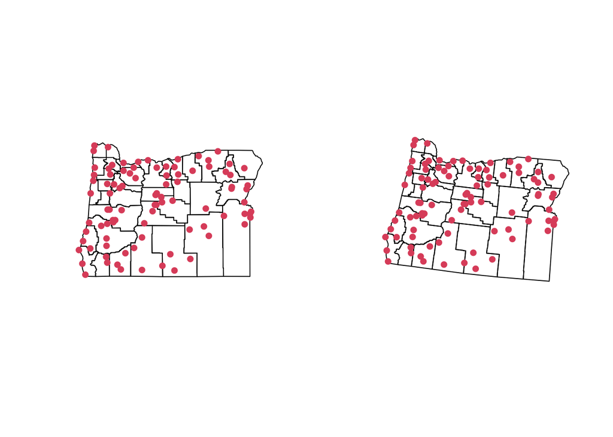

```r
summary(ortann)
summary(ortann.proj)
par(mfrow=c(1,2))
plot(orotl)
plot(ortann, col=2, pch=16, add=TRUE)
plot(orotl.proj)
plot(ortann.proj, col=2, pch=16, add=TRUE)
```

There are many other projections (and parameters) available in the PROJ4 library, and more details and examples can be found [here](http://trac.osgeo.org/proj/).

## Visualizing spatial data

The basic plotting function provided with the **sp** package, `spplot()` provides a simple way to map out data with a simple color scale (e.g. `spplot(NY8[,"POP8"])`). This has several arguments that can improve on the basic maps. The following examples demonstrate the use of some of these, and require two extra packages to be installed: **classInt** (provides methods for selecting data intervals for colors) and **RColorBrewer** (provides better color palettes).